Curso R - Aula 4 Dennis Leão abril 12, 2019

# Inferência e regressão

## Introdução

O site [Gapminder](http://www.gapminder.org/) compilou uma base de dados com a população, expectativa de vida, e PIB per capta de 142 países, em 12 anos diferentes.

## Dados

Os dados do Gapminder mencionados estão disponíveis neste [endereço](http://www.leg.ufpr.br/~fernandomayer/data/pib_gapminder.csv).

Com isso:

- Faça a importação dos dados, verifique sua estrutura e faça um sumário estatístico.

```r
## Importação
url <- "http://www.leg.ufpr.br/~fernandomayer/data/pib_gapminder.csv"
dados <- read.table(url, header = TRUE, sep = ",", dec = ".")
```

- Verifique a estrutura dos dados

```r
## Estrutura
str(dados)
```

```
## 'data.frame':    1704 obs. of  6 variables:
##  $ pais      : Factor w/ 142 levels "Afghanistan",..: 1 1 1 1 1 1 1 1 1 1 ...
##  $ ano       : int  1952 1957 1962 1967 1972 1977 1982 1987 1992 1997 ...
##  $ pop       : num  8425333 9240934 10267083 11537966 13079460 ...
##  $ continente: Factor w/ 5 levels "Africa","Americas",..: 3 3 3 3 3 3 3 3 3 3 ...
##  $ expVida   : num  28.8 30.3 32 34 36.1 ...
##  $ pibPercap : num  779 821 853 836 740 ...
```

- Classifique cada variável de acordo com seu tipo (ex.: qualitativa ordinal, etc)

## Análise exploratória

- Faça um sumário estatístico dos dados

```r
## Sumário
summary(dados)
```

```
##           pais           ano            pop               continente
##  Afghanistan:  12   Min.   :1952   Min.   :6.001e+04   Africa  :624
##  Albania    :  12   1st Qu.:1966   1st Qu.:2.794e+06   Americas:300
##  Algeria    :  12   Median :1980   Median :7.024e+06   Asia    :396
##  Angola     :  12   Mean   :1980   Mean   :2.960e+07   Europe  :360
##  Argentina  :  12   3rd Qu.:1993   3rd Qu.:1.959e+07   Oceania : 24
##  Australia  :  12   Max.   :2007   Max.   :1.319e+09
##  (Other)    :1632
##     expVida        pibPercap
##  Min.   :23.60   Min.   :   241.2
##  1st Qu.:48.20   1st Qu.:  1202.1
##  Median :60.71   Median :  3531.8
##  Mean   :59.47   Mean   :  7215.3
##  3rd Qu.:70.85   3rd Qu.:  9325.5
##  Max.   :82.60   Max.   :113523.1
##
```

- Faça uma tabela de frequência absoluta e uma tabela de frequência relativa para verificar o número de observações por continente.

```r
table(dados$continente)
```

```
##
##   Africa Americas     Asia   Europe  Oceania
##      624      300      396      360       24
```

```r
prop.table(table(dados$continente))
```

```
##
##     Africa   Americas       Asia     Europe    Oceania
## 0.36619718 0.17605634 0.23239437 0.21126761 0.01408451
```

- Faça um gráfico de barras da tabela de frequência absoluta dos continentes

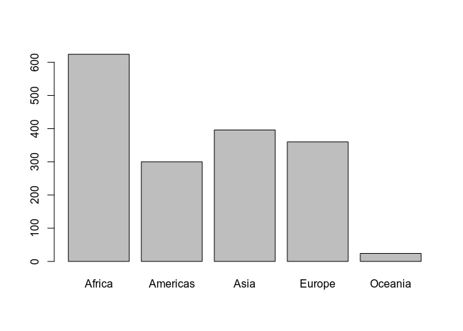

```r
barplot(table(dados$continente))
```

- Faça um gráfico apropriado para relacionar o PIB per capita (variável `pibPercap`) à expectativa de vida (variável `expVida`). Assume-se que quanto maior for o PIB per capta, maior será a expectativa de vida, ou seja, a expectativa de vida é a variável dependente.

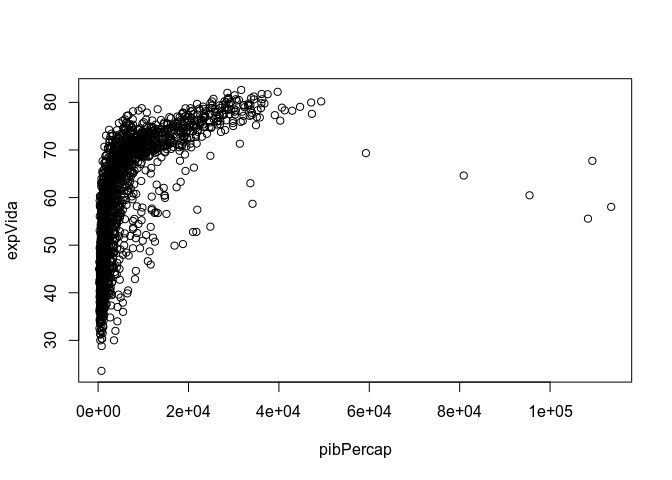

```r
plot(expVida ~ pibPercap, data = dados)
```

- Em uma mesma janela gráfica, faça um gráfico de caixa (*boxplot*) da expectativa de vida para o Chile, e outro *boxplot* para a expectativa de vida no Uruguai.

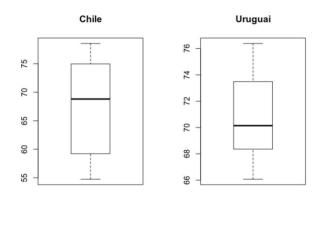

```r
par(mfrow = c(1,2))
boxplot(dados$expVida[dados$pais == "Chile"], main = "Chile")
boxplot(dados$expVida[dados$pais == "Uruguay"], main = "Uruguai")
```

```r
par(mfrow = c(1,1))
```

- Calcule a média e a variância da expectativa de vida para o Chile e para o Uruguai.

```r
mean(dados$expVida[dados$pais == "Chile"])
```

```
## [1] 67.43092
```

```r
var(dados$expVida[dados$pais == "Chile"])
```

```
## [1] 75.1921
```

```r
mean(dados$expVida[dados$pais == "Uruguay"])
```

```
## [1] 70.78158
```

```r
var(dados$expVida[dados$pais == "Uruguay"])
```

```
## [1] 11.17523
```

## Inferência sobre a média da expectativa de vida

Sabemos que o intervalo de confiança para média de uma distribuição normal com variância desconhecida, para uma amostra de tamanho $n$ é dado por:

$$\left(\bar{x} - t_{crit} \sqrt{\frac{s^2}{n}} \quad, \quad
\bar{x} + t_{crit} \sqrt{\frac{s^2}{n}} \right)$$

onde $t_{crit}$ é o quantil de ordem $1-\alpha/2$ da distribuição $t$ de Student, com $n-1$ graus de liberdade.

Considerando que estamos interessados em obter um intervalo de confiança para a média da expectativa de vida (`expVida`), faça o que se pede:

- Calcule o tamanho da amostra, a média e a variância amostral da coluna `expVida`

```r
## Tamanho da amostra (n), média e variância de Venda
n <- length(dados$expVida)
n
```

```
## [1] 1704
```

```r
t.m <- mean(dados$expVida)
t.m
```

```
## [1] 59.47444
```

```r
t.v <- var(dados$expVida)
t.v
```

```
## [1] 166.8517
```

- Monte o intervalo de confiança utilizando os quantis da distribuição $t$, para obter um IC de 95% de confiança.

```r
## IC com 95% de confiança
t.ic <- t.m + qt(c(0.025, 0.975), df = n - 1) * sqrt(t.v/n)
t.ic
```

```
## [1] 58.86070 60.08818
```

Além do intervalo de confiança, podemos realizar um teste de hipótese para testar se a média da expectativa de vida é igual a determinado valor. Os procedimentos gerais para este teste de hipótese são:

1. Definir a hipótese nula ($H_0$) e a alternativa ($H_1$)
2. Definir um nível de **significância** $\alpha$ (ex.: $\alpha = 0,05$), que irá determinar o nível de **confiança** $100(1-\alpha)\%$ do teste
3. Determinar a **região de rejeição** com base no nível de significância $\rightarrow$ valor crítico
4. Calcular a **estatística de teste**, sob a hipótese nula
   $$t_{calc} = \frac{\bar{x} - \mu_0}{s/\sqrt{n}}$$
5. Rejeitar a hipótese nula se a estatística de teste calculada estiver dentro da região de rejeição ($|t_{calc}| > |t_{crit}|$)

Portanto, se desejamos testar a hipótese de que a expectativa de vida média é igual a 60, temos as seguintes hipóteses:

$$\begin{align}
\text{H}_0: \mu = 60 \\
\text{H}_1: \mu \neq 60 \\
\end{align}$$

Usando um nível de significância $\alpha = 0,05$, realize este teste de hipótese usando a função `t.test()`.

```r
t.test(dados$expVida, mu = 60)
```

```
##
##  One Sample t-test
##
## data:  dados$expVida
## t = -1.6795, df = 1703, p-value = 0.09323
## alternative hypothesis: true mean is not equal to 60
## 95 percent confidence interval:
##  58.86070 60.08818
## sample estimates:
## mean of x
##  59.47444
```

Qual a sua conclusão a respeito do teste de hipótese?

## Ajustando um modelo linear

Queremos ajustar um modelo linear para a relação entre o **logaritmo** do PIB per capta, e o **logaritmo** da expectativa de vida.

Por isso, crie duas novas colunas nesta base de dados com o logaritmo de PIB per capta, e o logaritmo da expectativa de vida. Estas colunas devem ter os nomes: `lpibPercap`, e `lexpVida`, respetivamente.

```r
dados$lpibPercap <- log(dados$pibPercap)
dados$lexpVida <- log(dados$expVida)
```

Faça um gráfico apropriado para relacionar estas duas novas variáveis.

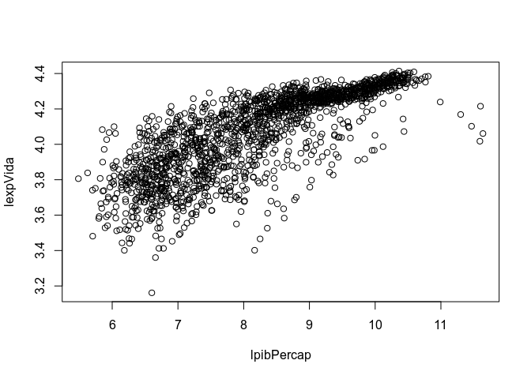

```r
plot(lexpVida ~ lpibPercap, data = dados)
```

Um **modelo linear** entre duas variáveis $X$ e $Y$, é definido matematicamente como uma equação com dois parâmetros desconhecidos,

$$Y = \beta_0 + \beta_1 X$$

Assim, dados $n$ pares de valores, $(X_1, Y_1), (X_2, Y_2), \ldots, (X_n, Y_n)$, se for admitido que $Y$ é função linear de $X$, pode-se estabelecer uma regressão linear simples, cujo modelo estatístico é

$$Y_i = \beta_0 + \beta_1 X_i + e_i, \quad i = 1, 2, \ldots, n$$

Como através de uma amostra obtemos uma estimativa da verdadeira equação de regressão, denominamos

$$\hat{Y}_i = \hat{\beta}_0 + \hat{\beta}_1 X_i$$

ou seja, $\hat{Y}_i$ é o valor **estimado** de $Y_i$, através das **estimativas** de $\beta_0$ e $\beta_1$, que chamaremos de $\hat{\beta}_0$ e $\hat{\beta}_1$. Para cada valor de $Y_i$, temos um valor $\hat{Y}_i$ estimado pela equação de regressão,

$$Y_i = \hat{Y}_i + e_i$$

Portanto, o erro (ou desvio) de cada observação em relação ao modelo adotado será

$$\begin{align}
e_i &= Y_i - \hat{Y}_i \\
e_i &= Y_i - (\beta_0 + \beta_1 X_i)
\end{align}$$

Devemos então adotar um modelo cujos parâmetros $\beta_0$ e $\beta_1$, tornem esse diferença a menor possível. Isso equivale a **minimizar** a **soma de quadrados dos resíduos** ($SQR$), ou do erro,

$$SQR = \sum_{i=1}^{n} [Y_i - (\beta_0 + \beta_1 X_i)]^2$$

O método de minimizar a soma de quadrados dos resíduos é denominado de **método dos mínimos quadrados**. Para se encontrar o ponto mínimo de uma função, temos que obter as derivadas parciais em relação a cada parâmetro,

$$\begin{align*}
\frac{\partial SQR}{\partial \beta_0} &= 2 \sum_{i=1}^{n} [Y_i -
\beta_0 - \beta_1 X_i] (-1) \\
\frac{\partial SQR}{\partial \beta_1} &= 2 \sum_{i=1}^{n} [Y_i -
\beta_0 - \beta_1 X_i] (-X_i)
\end{align*}$$
e igualar os resultados a zero
$$\hat{\beta}_0 = \frac{\partial SQR}{\partial \beta_0} = 0 \qquad
\text{e} \qquad
\hat{\beta}_1 = \frac{\partial SQR}{\partial \beta_1} = 0$$

Dessa forma, chegamos às **estimativas de mínimos quadrados** para os parâmetros $\beta_0$ e $\beta_1$:

$$\begin{align}
\hat{\beta}_1 &= \frac{\sum_{i=1}^{n} X_iY_i - \frac{\sum_{i=1}^{n}
X_i \sum_{i=1}^{n} Y_i}{n}}{\sum_{i=1}^{n}X_i^2 -
\frac{(\sum_{i=1}^{n} X_i)^2}{n}} \\
& \\
\hat{\beta_0} &= \bar{Y} - \hat{\beta}_1 \bar{X}
\end{align}$$

onde

$$\begin{align}
\bar{Y} = \frac{1}{n} \sum_{i=1}^{n} Y_i \qquad \text{e} \qquad
\bar{X} = \frac{1}{n} \sum_{i=1}^{n} X_i
\end{align}$$

Como vimos pelas soluções acima, primeiro calculamos $\hat{\beta_1}$, e depois $\hat{\beta_0}$. Para facilitar as contas, vamos criar objetos `X` e `Y` com as colunas `lpibPercap` e `lexpVida` (saber quem é `X` e quem é `Y` faz parte da interpretação do problema), e `n` que é o tamanho da amostra

```r
## Defina X, Y, e n
X <- dados$lpibPercap
Y <- dados$lexpVida
n <- length(X)
```

Agora calculamos $\hat{\beta_1}$ com a solução acima

```r
## Crie um objeto chamado beta1
beta1 <- (sum(X * Y) - (sum(X) * sum(Y))/n)/(sum(X^2) - (sum(X)^2/n))
beta1
```

```
## [1] 0.146549
```

E $\hat{\beta_0}$ com a solução acima

```r
## Crie um objeto chamado beta0
beta0 <- mean(Y) - beta1 * mean(X)
beta0
```

```
## [1] 2.864177
```

Para conferir os seus cálculos e prosseguir com a análise, ajuste um modelo linear entre as duas variáveis consideradas, usando a função `lm()`, e verifique se os coeficientes estimados pela função são os mesmos que você calculou à mão.

```r
## Crie um objeto chamado mod com o modelo ajustado
mod <- lm(lexpVida ~ lpibPercap, data = dados)
mod
```

```
##
## Call:
## lm(formula = lexpVida ~ lpibPercap, data = dados)
##
## Coefficients:
## (Intercept)   lpibPercap
##      2.8642       0.1465
```

Para avaliar a significância do modelo, podemos realizar uma **Análise de Variância** (ANOVA) para a regressão. Como vimos na estimação dos parâmetros, o objetivo é encontrar parâmetros que façam com que a soma de quadrados dos resíduos seja mínima. Podemos particionar a soma de quadrados da seguinte forma:

$$SQTot = SQMod + SQRes$$

Portanto, se um modelo é bem ajustado, esperamos que a soma de quadrados do modelo $SQMod$ seja grande, e a $SQRes$ sejá mínima. Um quadro de ANOVA para o modelo irá testar, através de um teste F, se a soma de quadrados do modelo é significativamente diferente de zero. Para fazer essa ANOVA, usamos a função `anova()`

```r
## Quadro de Análise de Variância
anova(mod)
```

```
## Analysis of Variance Table
##
## Response: lexpVida
##              Df Sum Sq Mean Sq F value    Pr(>F)
## lpibPercap    1 56.343  56.343  2698.2 < 2.2e-16 ***
## Residuals  1702 35.540   0.021
## ---
## Signif. codes:  0 '***' 0.001 '**' 0.01 '*' 0.05 '.' 0.1 ' ' 1
```

Uma parte importante em uma análise de regressão linear é a verificação dos resíduos do modelo, ou seja, os desvios de cada valor observado $Y$ em relação aos valores **preditos** pelo modelo, $\hat{Y}$. O modelo linear mais simples supõe que os resíduos possuam uma distribuição normal com média 0 e variância constante, $e_i \sim \text{N}(0, \sigma^2)$, então podemos verificar essa suposição fazendo um histograma destes resíduos. Para isso, podemos extrair os resíduos diretamente do objeto `mod` com a função `residuals()`, e fazer o histograma destes resíduos

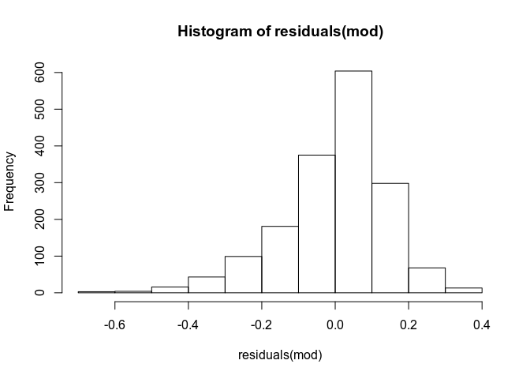

```r
## Faça um histograma dos resíduos do modelo
hist(residuals(mod))
```

o objeto `mod` é da classe lm, que possui um método específico para a função `plot()`. Por padrão, ao fazer um gráfico de um objeto da classe lm, são gerados quatro gráficos de diagnóstico, como pode ser visto abaixo.

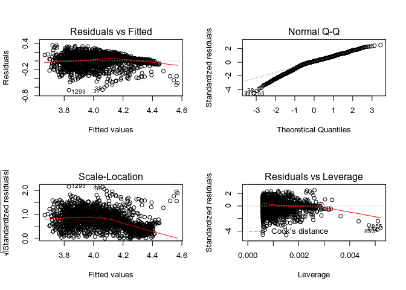

```r
par(mfrow = c(2,2))
plot(mod)
par(mfrow = c(1,1))
```

Ainda com o objeto `mod`, podemos ajustar o modelo graficamente ao gráfico da relação entre as variáveis. Para isso, usamos uma função `abline()`, utilizada para inserir linhas em gráficos.

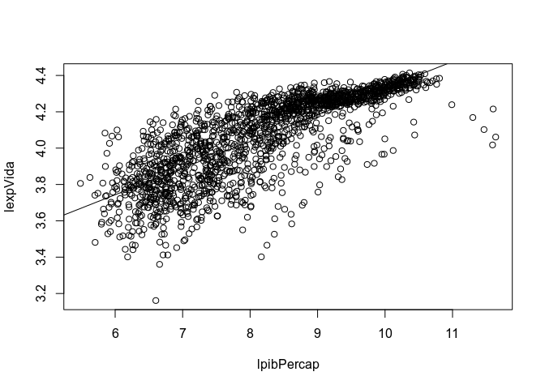

```r
## Faça o gráfico da relação entre entre as variáveis, e insira a
## linha do modelo com abline()
plot(lexpVida ~ lpibPercap, data = dados)
abline(mod)
```

# Modelo de Regressão Logística

Talvez a maneira mais rápida de entender a regressão logística seja comparando-a diretamente à regressão linear. Nós vamos fazer exatamente isso. Primeiro, vamos olhar para a teoria e depois passaremos para a implementação.

Tanto a regressão linear como a regressão logística são tipos de modelos lineares generalizados (GLMs). Matematicamente, os GLMs podem ser expressos como

$$Y\left|\mathbf{X}=\mathbf{x} \sim N\left(\beta_{0}+\beta_{1} x_{1}+\ldots+\beta_{p-1} x_{p-1}, \sigma^{2}\right)\right.$$

A estrutura de regressão logística da forma GLM é fácil de ver quando se observam equações generalizadas para regressão linear e logisítica. Lembre-se de que os modelos de regressão linear são definidos pela equação

$$Y=\beta_{0}+\beta_{1} x_{1}+\ldots+\beta_{q} x_{q}+\epsilon, \epsilon \sim N\left(0, \sigma^{2}\right)$$

que calcula a resposta Y diretamente. A regressão de logisitc é definida de maneira semelhante

$$\log \left(\frac{p(\mathbf{x})}{1-p(\mathbf{x})}\right)=\beta_{0}+\beta_{1} x_{1}+\ldots+\beta_{p-1} x_{p-1}$$

No entanto, em contraste com a regressão linear, observe que o cálculo da resposta não é direto.

O lado da equação com a variável de resposta é conhecido como log-chance.

Em um contexto binário, as probabilidades são a probabilidade de um evento “positivo” $(Y=1)$ dividida pela probabilidade de um evento “negativo” $(Y=0)$.

$$\frac{p(\mathbf{x})}{1-p(\mathbf{x})}=\frac{P[Y=1 | \mathbf{X}=\mathbf{x}]}{P[Y=0 | \mathbf{X}=\mathbf{x}]}$$

A equação de regressão logística garante que um valor entre 0 e 1 seja calculado. Isso é evidente quando a transformação logit inversa é aplicada, o que resulta em uma previsão de probabilidade “direta”.

$$E(Y | \mathbf{x})=P(Y=1 | \mathbf{x})=p(\mathbf{x})=\frac{\exp \left\{\beta_{0}+\sum_{k=1}^{p} \beta_{k} x_{k}\right\}}{1+\exp \left\{\beta_{0}+\sum_{k=1}^{p} \beta_{k} x_{k}\right\}}$$

$$1-p(\mathbf{x})=\frac{1}{1+\exp \left\{\beta_{0}+\sum_{k=1}^{p} \beta_{k} \mathrm{x}_{k}\right\}}$$

$$p(\mathbf{x})=\frac{\exp \left\{\beta^{\prime} \mathbf{x}\right\}}{1+\exp \left\{\beta^{\prime} \mathbf{x}\right\}} \quad e \quad 1-p(\mathbf{x})=\frac{1}{1+\exp \left\{\beta^{\prime} \mathbf{x}\right\}}$$

$$\ln \left(\frac{p(\mathbf{x})}{1-p(\mathbf{x})}\right)=\beta_{0}+\sum_{k=1}^{p} \beta_{k} \mathrm{x}_{k}=\beta^{\prime} \mathbf{x}$$

Note que esta é uma previsão de probabilidade, não um valor numérico. Esse valor de probabilidade deve ser traduzido em uma previsão categórica.

## Sumário Teórico

Então, o que isso tudo significa? Em termos simples, a regressão linear deve ser usada para prever uma variável de resposta quantitativa (ou seja, numérica), enquanto a regressão logística deve ser usada para prever uma variável de resposta qualitativa (ou seja, categórica). Visualmente, o modelo linear gera uma linha reta e o modelo logístico gera uma curva “S”.

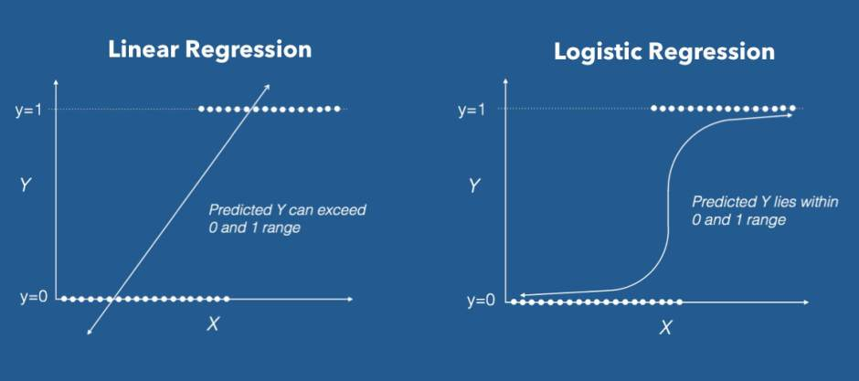

## Implementação de um Modelo Logístico

Para este tutorial, usaremos o conjunto de dados padrão do pacote ISLR.

```r
library("ISLR")
library("tibble")
library('ggplot2')
data <- as_tibble(Default)
```

Nosso objetivo é classificar corretamente as pessoas que entraram em default com base no status do aluno, no saldo do cartão de crédito e na renda.

## Inspeção Visual nos Dados

É sempre uma boa ideia visualizar nossos dados antes de tentar criar um modelo para isso. Por exemplo, os gráficos de densidade são úteis para identificar a distribuição dos preditores em relação um ao outro e a variável de resposta.

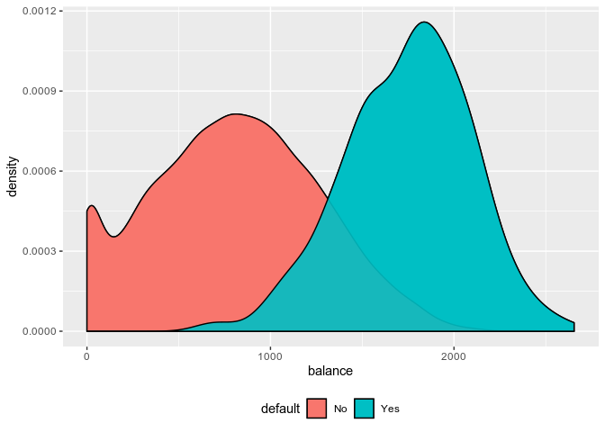

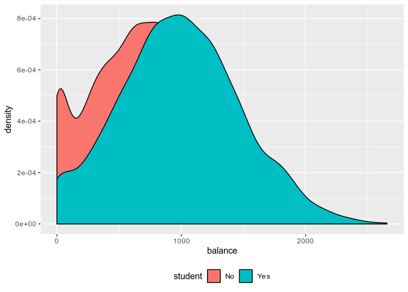

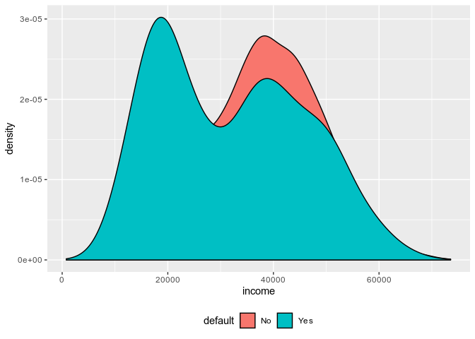

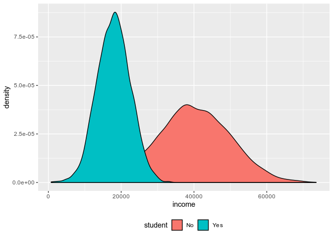

Observando que as distribuições de “Não” e “Sim” para a renda padrão dada não diferem muito, podemos acreditar que a renda não será particularmente útil para o nosso modelo. Por outro lado, parece haver uma grande diferença nas distribuições de saldo em um valor de cerca de 1400 para as duas categorias de default.

Podemos observar também a distribuição de renda e equilíbrio com o outro preditor, que é qualitativo (como padrão). Esses gráficos de densidade indicam que os estudantes têm muito menos renda do que o restante da população.

## Criação do Modelo Logístico

Embora pudéssemos fazer mais para inspecionar os dados, vamos em frente e criar um modelo de regressão logística. Para implementar boas práticas de modelagem, criaremos divisões de treinamento e teste para tentar evitar sub-ajustes ao realizar a regressão.

```r
# Dividir Entre Teste e Ajuste
set.seed(42)
default_idx <- sample(nrow(data), ceiling(nrow(data) / 2))
default_trn <-  Default[default_idx, ]
default_tst <- Default[-default_idx, ]

# Criar Modelo
model_glm <- glm(default ~ balance, data = default_trn, family = "binomial")
```

A criação de um modelo de regressão logística deve ser muito semelhante à criação de um modelo de regressão linear. Contudo ao invés de `lm()` nś usamos `glm()`. Também, note que precisamos especificar a família = “binomial” para um contexto de classificação dicotômica. (Na verdade se usarmos glm() com o argumento `family = "gaussian"` seria equivalente ao `lm()`.)

Antes de fazer qualquer previsão, vamos examinar brevemente o modelo com summary (). Entre outras coisas, é importante ver quais valores de coeficiente foram estimados para o nosso modelo.

```r
summary(model_glm)
```

```
##
## Call:
## glm(formula = default ~ balance, family = "binomial", data = default_trn)
##
## Deviance Residuals:
##     Min       1Q   Median       3Q      Max
## -2.2227  -0.1560  -0.0634  -0.0237   3.7286
##
## Coefficients:
##               Estimate Std. Error z value Pr(>|z|)
## (Intercept) -10.452183   0.500042  -20.90   <2e-16 ***
## balance       0.005368   0.000306   17.54   <2e-16 ***
## ---
## Signif. codes:  0 '***' 0.001 '**' 0.01 '*' 0.05 '.' 0.1 ' ' 1
##
## (Dispersion parameter for binomial family taken to be 1)
##
##     Null deviance: 1470.42  on 4999  degrees of freedom
## Residual deviance:  830.61  on 4998  degrees of freedom
## AIC: 834.61
##
## Number of Fisher Scoring iterations: 8
```

Assim como os valores resumidos calculados para um modelo de regressão linear, obtemos informações quantílicas relativas a resíduos, bem como estimativas de significância para nossos preditores. A interpretação dos valores de p na estrutura de regressão logística é a mesma dos modelos de regressão linear. (Portanto, a regra de preditores “siginifcantes” associados a valores de p inferiores a 5% também é válida.)

# Predição através de um Modelo de Regressão Logística

No entanto, antes de examinar mais de perto os diagnósticos do modelo que são mais adequados para a regressão logística, devemos primeiro entender como usar a função predict () com glm (). Para retornar probabilidades, devemos especificar type = “response”. (A configuração padrão é type = “link”, que corresponde ao valor de log odds.)

```r
head(predict(model_glm, type = "response"))
```

```
##         9149         9370         2861         8302         6415
## 9.466353e-04 3.298300e-01 7.437969e-03 8.170105e-05 1.183661e-04
##         5189
## 6.357530e-04
```

Como mencionado anteriormente, esses valores previstos são probabilidades, não classificações. Devemos “manualmente” converter as probabilidades em classificações. Tradicionalmente, um valor de ponto médio, como 0,5, é usado para “categorizar” as probabilidades. (Isto é exatamente equivalente ao tipo específico = “link” e usando um valor limite de 0.)

```r
trn_pred <- ifelse(predict(model_glm, type = "response") > 0.5, "Yes", "No")
head(trn_pred)
```

```
## 9149 9370 2861 8302 6415 5189
## "No" "No" "No" "No" "No" "No"
```

# Avaliação e Prognósticos do Modelo

Provavelmente, a coisa mais comum que é feita para avaliar um modelo de classificação é comparar os valores de resposta reais com os previstos usando uma tabela cruzada, que é freqüentemente chamada de matriz de confusão. Essa matriz pode ser gerada com a função table () base.

```r
# Fazendo a predição no conjunto de treino
trn_tab <- table(predicted = trn_pred, actual = default_trn$default)
trn_tab
```

```
##          actual
## predicted   No  Yes
##       No  4815  122
##       Yes   17   46
```

```r
# Fazendo a predição no conjunto de teste
tst_pred <- ifelse(predict(model_glm, newdata = default_tst, type = "response") > 0.5, "Yes", "No")
tst_tab <- table(predicted = tst_pred, actual = default_tst$default)
tst_tab
```

```
##          actual
## predicted   No  Yes
##       No  4817  113
##       Yes   18   52
```

Talvez sem surpresa, as métricas mais comuns para avaliar os modelos de regressão logística são a taxa de erro e a precisão (que é simplesmente o inverso aditivo da taxa de erro). Essas métricas podem ser calculadas diretamente da matriz de confusões.

```r
calc_class_err <- function(actual, predicted) {
  mean(actual != predicted)
}

calc_class_err(actual = default_trn$default, predicted = trn_pred)
```

```
## [1] 0.0278
```

```r
# Test error rate should be close to train error rate if model is fitted properly.
calc_class_err(actual = default_tst$default, predicted = tst_pred)
```

```
## [1] 0.0262
```

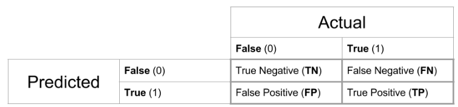

Agora, vamos considerar a matriz de confusão em mais detalhes. Os nomes verdadeiro positivo (TP), verdadeiro negativo (TN), falso positivo (FP) e falso negativo (FN) são freqüentemente usados para se referir às quatro células da matriz de confusão.

$$\begin{aligned} \text { Sens }=& \text { True Positive Rate }=\frac{\mathrm{TP}}{\mathrm{P}}=\frac{\mathrm{TP}}{\mathrm{TP}+\mathrm{FN}} \\ \mathrm{Spec}=& \text { True Negative Rate }=\frac{\mathrm{TN}}{\mathrm{N}}=\frac{\mathrm{TN}}{\mathrm{TN}+\mathrm{FP}} \\ & \text { Prev }=\frac{\mathrm{P}}{\text { Total Obs }}=\frac{\mathrm{TP}+\mathrm{FN}}{\text { Total Obs }} \end{aligned}$$

Cálculos de métricas como sensibilidade, especificidade e prevalência são derivados da matriz de confusão. A importância dessas (e outras) métricas depende da natureza dos dados (por exemplo, valores mais baixos podem ser aceitáveis se os dados são considerados difíceis de prever), bem como a tolerância para o tipo de erro de classificação. Por exemplo, podemos querer influenciar nossas previsões para classificar os padrões de modo que tenhamos mais probabilidade de prever o padrão quando um não ocorrer. Devemos identificar cuidadosamente se queremos priorizar sensibilidade ou especificidade.

Podemos obter os valores de sensibilidade, especificidade, prevalência, etc. facilmente para as nossas previsões usando a função `confusionMatrix()` do pacote `caret`.

```r
library("caret")
confusionMatrix(trn_tab, positive = "Yes")
```

```
## Confusion Matrix and Statistics
##
##          actual
## predicted   No  Yes
##       No  4815  122
##       Yes   17   46
##
##                Accuracy : 0.9722
##                  95% CI : (0.9673, 0.9766)
##     No Information Rate : 0.9664
##     P-Value [Acc > NIR] : 0.01101
##
##                   Kappa : 0.387
##  Mcnemar's Test P-Value : < 2e-16
##
##             Sensitivity : 0.2738
##             Specificity : 0.9965
##          Pos Pred Value : 0.7302
##          Neg Pred Value : 0.9753
##              Prevalence : 0.0336
##          Detection Rate : 0.0092
##    Detection Prevalence : 0.0126
##       Balanced Accuracy : 0.6351
##
##        'Positive' Class : Yes
##
```

Agora, vamos considerar outra métrica, não relacionada à matriz de confusão. Lembre-se de onde escolhemos o valor 0,5 como limite para classificação? Como sabemos que o valor 0.5 é o valor “ótimo” para a precisão. Na realidade, outros valores de corte podem ser melhores (embora 0,5 tenderá a ser o melhor valor se todas as suposições do modelo forem verdadeiras e o tamanho da amostra for razoavelmente grande).

A curva ROC (curva característica de operação do receptor) ilustra a sensibilidade e a especificidade de todos os possíveis valores de corte. Podemos usar a função roc () do pacote pROC para gerar a curva ROC para nossas previsões.

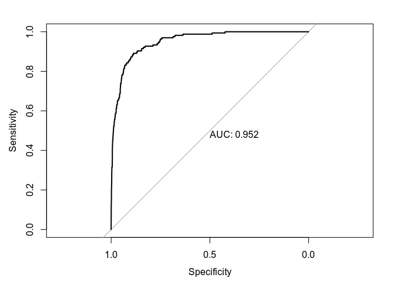

```r
library("pROC")
test_prob <- predict(model_glm, newdata = default_tst, type = "response")
test_roc <- roc(default_tst$default ~ test_prob, plot = TRUE, print.auc = TRUE)
```

Em geral, gostaríamos que a curva “abraçasse” o canto esquerdo superior do gráfico (indicando alta sensibilidade e especificidade). A AUC (área sob a curva) é usada para quantificar o perfil visual do ROC.

# Principais análises de Dados Categóricos

Exemplos de variáveis categóricas são, dentre outros, melhora do paciente (sim ou não), sintomas de uma doença (sim ou não), desempenho do candidato (bom, regular ou péssimo) e classe social (baixa, média ou alta).

Dependendo do delineamento amostral utilizado para obtenção dos da- dos, bem como dos objetivos para a análise dos mesmos, as variáveis de interesse podem ser classificadas em variáveis respostas ou explicativas.

A análise de dados dessa natureza é comumente denominada análise de dados categóricos. Isso porque distribuições discretas de probabilidade (binomial, Poisson, multinomial etc.) estão associadas à variável resposta. As demais variáveis envolvidas nesses estudos, as quais usualmente se tem interesse em verificar suas respectivas associações com a variável resposta, podem ser tanto categóricas quanto contı́nuas. Variáveis contı́nuas podem também ser categorizadas, seja por interesse do pesquisador ou por conveniência. Por exemplo, a idade pode ser categorizada em faixas etárias, bem como o resultado de um exame médico categorizado em normal ou anormal.

O peso, por sua vez, pode ser categorizado em obeso e não obeso ou, ainda, em intervalos tais como < 60, [60, 100), [100, 150) e ≥ 150 kg.

Por exemplo, algumas dessas variáveis apresentam duas categorias mutuamente exclusivas, outras três ou mais, bem como algumas apresentam uma ordenação natural das categorias e outras não. Variáveis categóricas que apresentam somente duas categorias são denominadas dicotômicas ou binárias. Já as que apresentam três ou mais categorias são denominadas politômicas. Em geral, variáveis categóricas são classificadas de acordo com sua escala de mensuração em ordinais ou nominais. As que apresentam categorias ordenadas são ditas ordinais.

Por exemplo: a) efeito produzido por um medicamento (nenhum, algum ou acentuado); b) grau de pureza da água (baixo, médio ou alto).

Nesses dois exemplos, nota-se a existência de uma ordem natural das categorias com as distâncias absolutas entre elas sendo, contudo, desconhecidas.

Em contrapartida, variáveis cujas categorias não exibem uma ordenação natural são ditas nominais.

Como exemplos tem-se: i) preferência de local para passar as férias (praia, montanha ou fazenda);

2. candidato de sua preferência (A, X, Y ou Z). Para essas variáveis, a ordem das categorias é irrelevante.

Algumas variáveis podem, ainda, apresentar um número finito de valores distintos. Assim, em vez de categorias, tais como sim e não ou baixo, médio e alto, tem-se valores inteiros (contagens discretas).

Alguns exemplos podem ser: i) número de filhos (1, 2, 3, 4 ou 5); ii) número de televisores em casa (0, 1, 2, 3 ou 4).

Variáveis dessa natureza são usualmente denominadas quantitativas do tipo discreto. Em geral, métodos utilizados para a análise de respostas categóricas (nominais ou ordinais) também se aplicam a variáveis dessa natureza, bem como àquelas que têm seus valores agrupados em categorias (por exemplo, anos de educação: < 5, 5 a 10 e > 10). Em certas situações, agrupar categorias se faz necessário devido à presença de categorias com frequências muito pequenas ou nulas.

Dados provenientes de estudos em que a variável resposta $Y$ e as variáveis explicativas $X = (X_1 , . . . , X_p )$ são categóricas (ou foram categorizadas) são usualmente dispostos nas, assim denominadas, tabelas de contingência.

Neste contexto, convencionou-se dispor as categorias da variável X nas linhas das tabelas de contingência e as da resposta Y nas colunas.

## Principais Estudos

### Estudos de Coorte

Ao conduzir um estudo de coorte o interesse está em avaliarmos se indivı́duos expostos a um determinado fator apresentam maior propensão ao desenvolvimento de certa doença do que indivı́duos não expostos ao fator. Fatores que aumentam o risco de adoecer são usualmente denominados “de risco”. Exposição a um fator de risco significa que um indivı́duo, antes de adoecer, esteve em contato com o fator em questão ou o manifestou. Um estudo de coorte é constituı́do, em seu inı́cio, de um grupo de indivı́duos, denominado coorte, em que todos estão livres da doença sob investigação. Os indivı́duos dessa coorte são classificados em expostos e não expostos ao fator de interesse obtendo-se dois grupos ou duas coortes de comparação. Essas coortes são observadas por um perı́odo de tempo, registrando-se os indivı́duos que desenvolvem e os que não desenvolvem a doença. Os indivı́duos expostos e não expostos devem ser comparáveis, ou seja, semelhantes quanto aos demais fatores, que não o de interesse, para que os resultados e as conclusões obtidas sejam confiáveis. Portanto, o termo coorte é utilizado para descrever um grupo de indivı́duo s que apresentam algo em comum ao serem reunidos e que são observados por um determinado perı́odo de tempo a fim de se avaliar o que ocorre com eles. É importante que todos os indivı́duos sejam observados por todo o perı́odo de seguimento, já que informações de uma coorte incompleta pode distorcer o verdadeiro estado das coisas.

Por outro lado, o perı́odo de tempo em que os indivı́duos serão observados deve ser significativo na história natural da doença em questão para que haja tempo suficiente de o risco se manifestar. Doenças com perı́odo de latência longa exigirão perı́odos longos de observação. Entenda-se por história natural da doença sua evolução sem intervenção médica e, por perı́odo de latência, o tempo entre a exposição ao fator e as primeiras manifestações da doença.

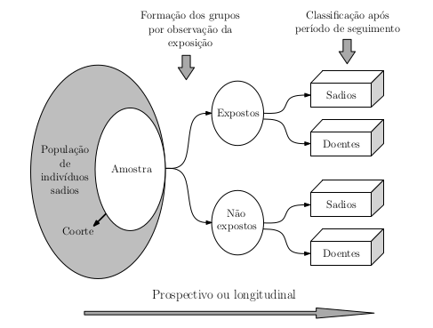

As principais dificuldades para a realização de um estudo de coorte são:

1. é um estudo demorado, que pode envolver custos elevados devido aos recursos necessários para acompanhar os indivı́duos ao longo do tempo estabelecido;
2. não disponibiliza resultados em curto prazo;
3. os indivı́duo sob estudo vivem livremente e não sob o controle do pesquisador, podendo ocorrer perda de seguimento de alguns deles;
4. não é viável para doenças raras.

### Estudos de Caso-Controle

O objetivo de um estudo caso-controle é essencialmente o mesmo de um estudo de coorte, o de avaliar se uma doença apresenta associação com um fator suspeito de ser de risco. Contudo, tais estudos se diferenciam dos estudos de coorte quanto à forma de seleção e de coleta de informações dos indivı́duos. Nos estudos caso-controle, o pesquisador seleciona um grupo de indivı́duos com uma determinada doença de interesse, denominados casos, e outro grupo de indivı́duos livres da doença, os controles.

A validade dos resultados desses estudos está condicionada, em particular, à forma de seleção dos indivı́duos. Os casos devem ser de preferência novos e os controles devem ser comparáveis aos casos, isto é, todas as diferenças importantes, que não o fator de interesse, devem ser controladas quando da escolha dos indivı́duos. Em outras palavras, casos e controles devem parecer ter tido chances iguais de exposição ao fator em questão. Os controles são, em geral, escolhidos segundo alguma estratégia que possa minimizar os vieses de seleção. Uma das possibilidades é a dos controles pareados aos casos, isto é, para cada caso, são selecionados um ou mais controles com algumas caracterı́sticas comuns aos casos. É usual o pareamento por caracterı́sticas demográficas (idade, sexo, raça etc.), porém deve-se também levar em conta outras caracterı́sticas reconhecidamente importantes. O pareamento apresenta, contudo, o risco de o pesquisador considerar, no pareamento, um fator que esteja relacionado à exposição. Outra estratégia é a seleção de mais de um grupo controle. A comparação dos casos com cada um deles pode trazer à tona potenciais vieses de seleção, pois, se forem observados resultados diferentes na comparação dos casos com os diferentes grupos controle, há evidências de que os grupos não são comparáveis. Desse modo, atenção e cuidado são necessários na seleção dos casos e dos controles para que a comparabilidade entre os grupos possa ser assegurada. Atenção também deve ser dada ao número de indivı́duos sob estudo, que deve ser suficientemente grande para que o acaso não interfira em demasia nos resultados. Uma vez selecionados os casos e os controles, registram-se os indivı́duos expostos e os não expostos ao fator sob investigação. Para esse fim, o pesquisador geralmente utiliza informações passadas, dependendo, assim, da disponibilidade e da qualidade dos registros existentes ou da memória dos pacientes. Evidentemente, isso pode ocasionar vieses de informação.

Por fazer uso de informações passadas, os estudos caso-controle são também denominados retrospectivos.

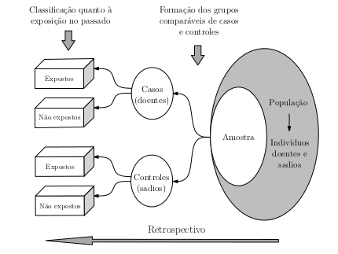

As principais vantagens dos estudos caso-controle são o custo e o tempo envolvidos para obtenção da resposta, fatores que são relativamente pequenos quando comparados aos de outros estudos como o de coorte. Por outro lado, tais estudos apresentam um particular problema, o de resultados propensos a vieses devidos, principalmente, às possı́veis manipulações dos grupos de comparação, bem como pela exposição ao fator de interesse ser medida por meio de informações passadas. Contudo, se a atenção apropriada for dada às possı́veis fontes de vı́cios, os estudos caso-controle podem ser válidos e eficientes para responder várias questões clı́nicas, em particular aquelas envolvendo doenças raras.

Se os dados apresentados na tabela de contingência tivessem sido obtidos por meio de um estudo caso-controle, nota-se que $n_{+1}$ e $n_{+2}$ é que teriam seus valores previamente estabelecidos (determinı́sticos) e não $n_{1+}$ e $n_{2+}$.

### Estudos Transversais

Nos estudos transversais (do inglês cross-sectional), informações sobre uma variedade de caracterı́sticas (variáveis) são coletadas simultaneamente de um grupo ou população de indivı́duos em um ponto especı́fico do tempo (ou durante um perı́odo bem curto). São estudos geralmente utilizados para investigar potenciais associações entre fatores suspeitos de serem de risco e a doença. Contudo, o fato de todas as informações serem coletadas em um ponto especı́fico do tempo limitam esses estudos em sua capacidade de fornecer conclusões quanto às associações, pois não se sabe se a exposição ocorreu antes, depois ou durante o aparecimento da doença. Sendo assim, fica difı́cil inferir causalidade. São estudos, no entanto, muito úteis para o direcionamento e o planejamento de novas pesquisas. Os estudos transversais podem ser vistos como avaliações fotográficas de grupos ou populações de indivı́duos, sendo o termo transversal usado para indicar que os indivı́duos estão sendo estudados em um ponto especı́fico do tempo (corte transversal). Um exemplo de estudo dessa natureza foi realizado com 1.080 crianças a fim de investigar se elas apresentavam sintomas de doenças respiratórias. Nesse estudo, cada criança foi examinada, registrando-se simultaneamente o sexo (feminino ou masculino) e a presença ou a ausência dos sintomas.

O esquema amostral de um estudo transversal em que as informações sobre a exposição a um fator de interesse e o status da doença foram coletadas simultaneamente.

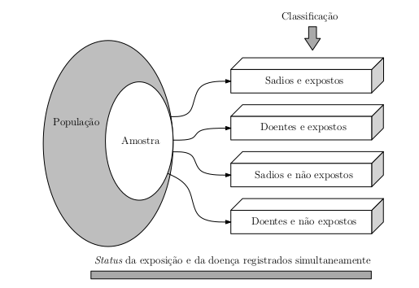

Em um estudo transversal, nota-se que somente o total amostral n é estabelecido no delineamento amostral. Assim, n é determinı́stico, enquanto os valores n ij , associados às variáveis aleatórias N ij , e os totais n i+ e n +j (i, j = 1, 2) dependem da realização do estudo para serem conhecidos. Observa-se, também, não fazer sentido falar em incidência ou prevalência nos estudos caso-controle descritos previamente, tendo em vista os totais de casos e de controles serem estabelecidos a priori.

### Ensaios Clínicos Aleatorizados

Os ensaios clı́nicos aleatorizados são realizados, em geral, com o objetiv de comparar dois ou mais tratamentos. Uma etapa importante no planejamento de tais ensaios é a de se estabelecer os indivı́duos elegı́veis. Adotar critérios de inclusão é, assim, uma prática usual nesses ensaios. Os indivı́duos podem ser, por exemplo, os que derem entrada em um hospital em um perı́odo estabelecido e que atendam certos critérios de elegibilidade (definidos entre os pesquisadores). Uma vez selecionados os indivı́duos, os tratamentos de interesse são alocados aleatoriamente aos mesmos, que passam a ser acompanhados para observação da resposta de interesse. Ensaios clı́nicos usualmente necessitam da aprovação de um comitê de ética para que possam ser realizados, bem como que cada participante assine um termo de consentimento livre e esclarecido para autorizar sua participação no estudo.

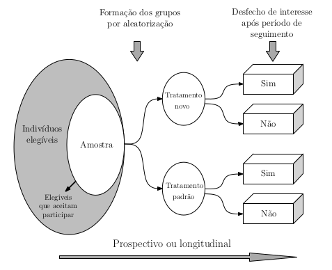

Nos ensaios clı́nicos, nota-se que o pesquisador intervém deliberadamente no curso natural dos acontecimentos, ou seja, impõe um dos tratamentos sendo pesquisados. Daı́ serem denominados estudos experimentais. Nos estudos de coorte, caso-controle e transversais, o pesquisador não intervém no curso natural dos acontecimentos, apenas participa como observador. São, assim, estudos observacionais. Semelhante aos estudosde coorte, nota-se que n 1+ e n 2+ são previamente estabelecidos nos ensaios clı́nicos (determinı́sticos), com os valores n ij , associados às variáveis N ij (i, j = 1, 2), dependendo da realização do ensaio para serem conhecidos.

Quando um ensaio clı́nico aleatorizado é realizado, há uma tendência dos participantes (pacientes, profissionais e avaliadores envolvidos) mudarem seus comportamentos por serem alvos de interesse e de atenção especial. Por exemplo, o fato de o paciente saber que está recebendo um tratamento novo pode ter um efeito psicológico benéfico e, ao contrário, saber que está recebendo um tratamento convencional, ou nenhum tratamento, pode exercer um efeito desfavorável. O entusiasmo do médico por um tratamento novo pode também ser transferido para o paciente e ocasionar uma mudança de atitude. Os avaliadores, por outro lado, podem registrar respostas mais favoráveis para o tratamento que acreditam ser superior. O não conhecimento dos grupos e o uso de placebos auxiliam a evitar esses vieses.

Ensaios clı́nicos em que os pacientes não conhecem o tratamento que estão recebendo são denominados ensaios cegos. O termo duplo cego é utilizado nos casos em que nem os pacientes nem os responsáveis pela sua assistência e avaliação conhecem o tratamento que está sendo administrado para cada paciente.

Nos estudos de Coorte e nos ensaios clínicos os indivíduos apresentam no início do experimento a mesma condição clínica. São então acompanhados por um período de tempo para observação de ocorrência de casos novos (por exemplo, de doença, de cura etc). Nesses estudos (coorte e ensaios clínicos) é possível a obtenção de uma medida denominada incidência. A incidência (seja de doença, de cura etc.) é definida como a proporçãoo de indivíduos em um determinado grupo que desenvolve a resposta de interesse ao longo do tempo de observação, isto é,

$$\text {Incidência} =\frac{\text { individuos que apresentaram resposta positiva no período de observaçäo }}{\text { total de individuos no inicio do experimento }}$$
Nos estudos transversais, indivíduos são, em um único ponto no tempo, investigados quanto a uma determinada resposta de interesse. Alguns dos indivíduos neste ponto do tempo apresentarão a resposta e outros não. Não é observado portanto casos novos ao longo do tempo. A medida adequada aqui é a prevalência, isto é, a proporcão de indivíduos do grupo com resposta positiva naquele ponto especíﬁco do tempo, isto é,

$$Prevalência =\frac{\text { individuos com a resposta em determinado ponto no tempo }}{\text { individuos pesquisados em determinado ponto no tempo }}$$

# Compreensão do Modelo Logístico

Para dados dispostos em tabelas de contingência é possível testarmos hipóteses uma vez que consideramos os delineamentos amostrais corretos.

Considere a tabela de contingência apresentada, cuja qual é uma maneira comum de resumir e representar dados categóricos.

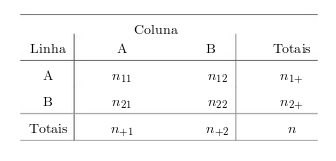

pode-se observar frequências, representadas por $n_{11},···,n_{22},n_{1+},···,n_{+2}, n$, associadas as diversas caselas. Os totais $n_{1+},n_{2+},n_{+1},n_{+2}$ são denominados totais marginais e n total ou tamanho amostral. Esses totais, ao serem considerados no delineamento amostral como ﬁxos ou aleatórios, indicam o modelo probabilístico a ser considerado.

Se, por exemplo, o experimento for realizado de modo que $n_{1+}$ e $n_{2+}$ sejam amostras aleatórias obtidas de dois grupos independentes e de tamanhos ﬁxos (isto é, de tamanhos estabelecidos antes da execução do experimento), tem-se duas distribuições binomiais independentes associadas a tabela, uma para cada linha. O modelo proba-bilístico associado a tabela, nessa situação, seria, portanto, o modelo produto de binomiais independentes de modo a ter-se:

$$P\left(N_{11}=n_{11}, N_{21}=n_{21}\right)=\prod_{i=1}^{2}\left\{n_{i+} ! \prod_{j=1}^{2} \frac{p_{i j}^{n_{i j}}}{n_{i j} !}\right\}$$

Logo devido a questões atreladas ao tempo de duração do curso e difícil formulação teórica uma melhor compreensão sobre os delineamentos amostrais de cada tipo de estudo foi deixado de lado para priorizarmos exemplos práticos.

Mas inerente à formulação teórica de cada estudo é possível de maneira intuitiva deduzir a ideia por trás de cada teste hipotético formulado.

Vejamos o exemplo:

| Medicamento | Melhora Sim | Melhora Não | Totais |
| --- | --- | --- | --- |
| Novo | 40 | 20 | 60 |
| Placebo | 16 | 48 | 64 |
| Totais | 56 | 68 | 124 |

Hipótese nula de interesse: hipótese de ausência de associação Hipótese alternativa de interesse: hipótese de presença de associação

$$H_{0} : {p}_{11}={p}_{21} \text { versus } H_{A} : {p}_{11} \neq {p}_{21}$$

Ou mesmo de outra maneira:

$$H_{0} : \frac{{p}_{11}}{{p}_{21}}= 1$$

$$H_{0} : \frac{\frac{{p}_{11}}{1-{p}_{11}}}{\frac{{p}_{21}}{1-{p}_{21}}}=1$$
E para as Estatísticas dos testes, muitas delas serão baseadas na Distribuição Qui-quadrado. Como por exemplo a Estatística $Q_p$

```r
n <- sum(dados[-3,-3])
dados[-3,-3]/n
```

```
##           [,1]      [,2]
## [1,] 0.3225806 0.1612903
## [2,] 0.1290323 0.3870968
```

```r
rel <- dados[-3,-3]/dados[-3,3]


fisher.test(dados[-3,-3], alternative="two.sided")
```

```
##
##  Fisher's Exact Test for Count Data
##
## data:  dados[-3, -3]
## p-value = 4.754e-06
## alternative hypothesis: true odds ratio is not equal to 1
## 95 percent confidence interval:
##   2.575436 14.136206
## sample estimates:
## odds ratio
##   5.902133
```

```r
options("scipen"=100, "digits"=4)
prettyNum(4.754e-06, format = "f", digits = 4, drop0trailing = TRUE)
```

```
## [1] "0.000004754"
```

Onde claramente rejeitamos a $H_{0}$.

## Medidas de Associação nas tabelas

Uma vez identificada associação nas tabelas poderemos descrever sua intensidade de algumas maneiras como:

- Risco Relativo (RR): Definido como a razão entre a probabilidade de resposta positiva entre os indivíduos expostos a um fator de interesse e esta mesma probabilidade entre os não expostos a este fator. O RR é sempre maior ou igual a zero. Se o RR for igual a 1, o risco de resposta positiva não difere nos indivíduos expostos e não expostos. Sendo maior que 1 o risco de se apresentar resposta positiva é maior no indivídos expostos e analogamente o contrário se for inferior a 1.

$$RR = \frac{P(D|E)}{P(D|\overline{E})} = \frac{p_{11}}{p_{21}}$$

```r
rel[1,1]/rel[2,1]
```

```
## [1] 2.667
```

- Razão de Chances (OR): Primeiro apresentaremos o conceito de chance.

$$chance=\frac{p(\mathbf{evento})}{1-p(\mathbf{evento})}=\exp \left\{\beta^{\prime} \mathbf{x}\right\}$$
Como no modelo Logístico a interpretação dos parâmetros baseia-se em razões de chances é fundamental sabermos a interpretação desta medida.

Basicamente se 10 pessoas são acompanhadas por duas semanas e 8 delas contrairam dengue, segue que a probabilidade estimada da doença é 80 %. Contudo a chance de ocorrência da doença é igual a 4 o que significa que a sua ocorrência é 4 vezes mais provavél do que sua não ocorrência. E similar ao RR, a OR também não assume valores negativos. Quando a OR = 1, não existe associação entre as variáveis (fator e doença). Já se OR > 1, a chance de doença entre os indivíduos expostos é maior do que entre os não expostos.

## Exemplos

### Doença Coronária e Idade

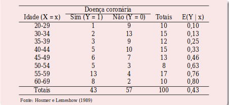

```r
   resim<-c(1,2,3,5,6,5,13,8)
   resnao<-c(9,13,9,10,7,3,4,2)
   idade<-c(25,32,38,43,47,53,57,65)
   dados<-as.data.frame(cbind(resim,resnao,idade))
   dados
```

```
##   resim resnao idade
## 1     1      9    25
## 2     2     13    32
## 3     3      9    38
## 4     5     10    43
## 5     6      7    47
## 6     5      3    53
## 7    13      4    57
## 8     8      2    65
```

```r
   attach(dados)

   theta<-resim/(resim+resnao)
   plot(idade, theta, ylim=range(0,0.9), xlab="Idade", ylab="E(Y|x)", pch=16)

   ajust<-glm(cbind(resim,resnao)~idade, family=binomial(link="logit"), data=dados)
   ajust
```

[output not shown]

```
##
## Call:  glm(formula = cbind(resim, resnao) ~ idade, family = binomial(link = "logit"),
##     data = dados)
##
## Coefficients:
## (Intercept)        idade
##      -5.123        0.106
##
## Degrees of Freedom: 7 Total (i.e. Null);  6 Residual
## Null Deviance:       28.7
## Residual Deviance: 0.584     AIC: 25.7
```

```r
   anova(ajust, test="Chisq")
```

```
## Analysis of Deviance Table
##
## Model: binomial, link: logit
##
## Response: cbind(resim, resnao)
##
## Terms added sequentially (first to last)
##
##
##       Df Deviance Resid. Df Resid. Dev   Pr(>Chi)
## NULL                      7      28.70
## idade  1     28.1         6       0.58 0.00000011 ***
## ---
## Signif. codes:  0 '***' 0.001 '**' 0.01 '*' 0.05 '.' 0.1 ' ' 1
```

```r
   summary(ajust)
```

```
##
## Call:
## glm(formula = cbind(resim, resnao) ~ idade, family = binomial(link = "logit"),
##     data = dados)
##
## Deviance Residuals:
##     Min       1Q   Median       3Q      Max
## -0.4465  -0.1889   0.0009   0.0924   0.4870
##
## Coefficients:
##             Estimate Std. Error z value Pr(>|z|)
## (Intercept)  -5.1230     1.1111   -4.61 0.000004 ***
## idade         0.1058     0.0234    4.53 0.000006 ***
## ---
## Signif. codes:  0 '***' 0.001 '**' 0.01 '*' 0.05 '.' 0.1 ' ' 1
##
## (Dispersion parameter for binomial family taken to be 1)
##
##     Null deviance: 28.70152  on 7  degrees of freedom
## Residual deviance:  0.58378  on 6  degrees of freedom
## AIC: 25.72
##
## Number of Fisher Scoring iterations: 4
```

```r
   cbind(ajust$fitted.values, ajust$y)
```

```
##      [,1]   [,2]
## 1 0.07738 0.1000
## 2 0.14957 0.1333
## 3 0.24912 0.2500
## 4 0.36022 0.3333
## 5 0.46226 0.4615
## 6 0.61856 0.6250
## 7 0.71229 0.7647
## 8 0.85231 0.8000
```

```r
   ajust$residuals
```

```
##         1         2         3         4         5         6         7
##  0.316803 -0.127638  0.004692 -0.116682 -0.002885  0.027312  0.255755
##         8
## -0.415520
```

```r
   dev<-residuals(ajust, type='deviance')
   dev
```

```
##         1         2         3         4         5         6         7
##  0.257025 -0.179071  0.007028 -0.218199 -0.005186  0.037564  0.487026
##         8
## -0.446493
```

```r
   QL<-sum(dev^2)
   p1<-1-pchisq(QL,6)
   cbind(QL,p1)
```

```
##          QL     p1
## [1,] 0.5838 0.9967
```

```r
   rpears<-residuals(ajust, type='pearson')
   rpears
```

```
##         1         2         3         4         5         6         7
##  0.267683 -0.176306  0.007030 -0.216944 -0.005186  0.037523  0.477368
##         8
## -0.466199
```

```r
   QP<-sum(rpears^2)
   p2<-1-pchisq(QP,6)
   cbind(QP,p2)
```

```
##          QP     p2
## [1,] 0.5965 0.9965
```

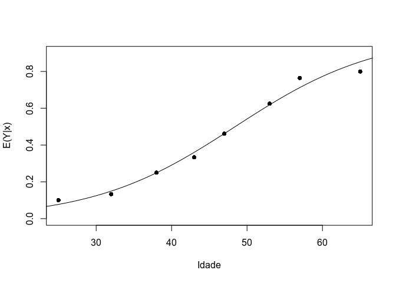

```r
   theta<-resim/(resim+resnao)
   plot(idade, theta, ylim=range(0,0.9), xlab="Idade", ylab="E(Y|x)", pch=16)
   idade<-20:70
   modajust<-(exp(-5.123+0.1058*idade))/(1+exp(-5.123+0.1058*idade))
   lines(idade, modajust)
```

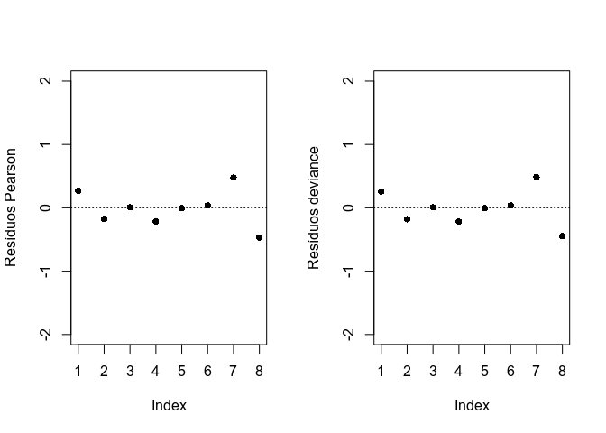

```r
   par(mfrow=c(1,2))
   plot(rpears, ylab="Resíduos Pearson", pch=16, ylim=c(-2,2))
   abline(h=0, lty=3)
   plot(dev, ylab="Resíduos deviance", pch=16, ylim=c(-2,2))
   abline(h=0, lty=3)
```

```r
  par(mfrow=c(1,1))
   ntot<-c(10,15,12,15,13,8,17,10)
   fit.model<-ajust
   fit.model
```

```
##
## Call:  glm(formula = cbind(resim, resnao) ~ idade, family = binomial(link = "logit"),
##     data = dados)
##
## Coefficients:
## (Intercept)        idade
##      -5.123        0.106
##
## Degrees of Freedom: 7 Total (i.e. Null);  6 Residual
## Null Deviance:       28.7
## Residual Deviance: 0.584     AIC: 25.7
```

$$\begin{array}{c}{\widehat{\beta}_{0}=-5,123(\text { e.p. }=1,11) \text { e } \widehat{\beta}_{1}=0,1058(\text { e.p. }=0,023) .} \\ {\widehat{p}(\mathbf{x})=\frac{\exp \{-5,123+0,1058 \mathrm{x}\}}{1+\exp \{-5,123+0,1058 \mathrm{x}\}}} \\ {\ln \left(\frac{\hat{p}(\mathbf{x})}{1-\widehat{p}(\mathbf{x})}\right)=-5,123+0,1058 \mathrm{x}}\end{array}$$
## ECG e Sexo

Os dados apresentados na tabela referem-se a um estudo realizado com pa-cientes que procuraram uma determinada clínica para serem submetidos a um eletro-cardiagrama (ECG). A variável resposta, presençaa ou ausência de doença coronária arterial, bem como as covariáveis sexo e ECG, são dicotômicas.

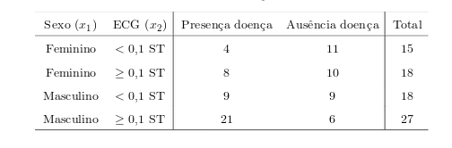

Assumindo-se que a variável resposta apresenta distribuição binomial (uma para cada linha da tabela) de modo que tem-se, associado a tabela, o modelo produto de binomias independentes, pode-se utilizar o modelo de regressão logístico para descrevera variação entre os $θ_{i1}(\mathbf{x})$, isto é,

$$\theta_{i 1}(\mathbf{x})=\frac{\exp \left\{\beta_{0}+\beta_{1} x_{1}+\beta_{2} x_{2}\right\}}{1+\exp \left\{\beta_{0}+\beta_{1} x_{1}+\beta_{2} x_{2}\right\}}$$
em que $β_0$ é o intercepto e, $β_1$ e $β_2$, são os parâmetros desconhecidos associados as covariáveis sexo e ECG, respectivamente.

Assim:

$$\log \left(\frac{\theta_{i 1}(\mathbf{x})}{1-\theta_{i 1}(\mathbf{x})}\right)=\operatorname{logit}\left(\theta_{i 1}(\mathbf{x})\right)=\beta_{0}+\beta_{1} x_{1}+\beta_{2} x_{2}$$

o, que matricialmente corresponde a:

$$\left[ \begin{array}{ccc}{1} & {0} & {0} \\ {1} & {0} & {1} \\ {1} & {1} & {0} \\ {1} & {1} & {1}\end{array}\right] \left[ \begin{array}{l}{\beta_{0}} \\ {\beta_{1}} \\ {\beta_{2}}\end{array}\right]$$

Como a combinaçao sexo feminino e ECG<0,1 sao descritas pelo intercepto, esse grupo é conhecido, nessa parametrização, como a combinação de referencia. O parametro $β_1$ é o incremento no logito para o sexo masculino e $β_2$ é o incremento no logito para ECG ≥ 0,1. As probabilidades e odds preditas para esse modelo são, portanto,

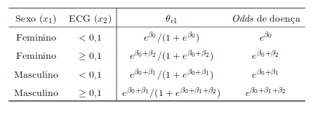

Desse modo, obter a odds ratio para pacientes do sexo masculino versusas do sexo feminino por:

$$\frac{e^{\beta_{0}+\beta_{1}}}{e^{\beta_{0}}}=e^{\beta_{1}} \quad \text { ou } \quad \frac{e^{\beta_{0}+\beta_{1}+\beta_{2}}}{e^{\beta_{0}+\beta_{2}}}=e^{\beta_{1}}$$
Similarmente, a odds ratio para alto ECG versus baixo ECG é determinado por:

$$\frac{e^{\beta_{0}+\beta_{1}+\beta_{2}}}{e^{\beta_{0}+\beta_{1}}}=e^{\beta_{2}} \quad \text { ou } \quad \frac{e^{\beta_{0}+\beta_{2}}}{e^{\beta_{0}}}=e^{\beta_{2}}$$
Em regressão logística, as odds ratio são, portanto, funções dos parâmetros do modelo. Para modelos com somente efeitos principais, cada odds, que compõem a odds ratio, é obtida simplesmente exponenciando as estimativas dos parâmetros. Contudo, diferentemente das odds ratio obtidas de tabelas 2×2, estas são ajustadas para todas as outras covariaveis no modelo.

Para o modelo ajustado e expresso por:

$$\operatorname{logit}\left(\hat{\theta}_{i 1}(\mathbf{x})\right)=-1,1747+1,277 \operatorname{sexo}+1,0545 \space\mathrm{ECG}$$

obtiveram-se QP = 0,2155 (p = 0,6425) e QL= 0,2141 (p= 0,6436) e, sendo assim, não se rejeita a hipótese nula H0 de que o modelo ajustado é satisfatório.

Tem-se, então, que a odds ratio dos pacientes do sexo masculino versus a dos pacientes do sexo feminino pode ser estimada, como visto anteriormente, por $OR_{(m / f)} = e^{1,277}=3,586$. Homens, nesse estudo, tˆem, portanto, odds 3,5 vezes maior de doen¸cacoron´aria arterial do que a odds das mulheres. De modo analogo, a odds ratio estimadade ECG ≥ 0,1 versus a de ECG<0,1 é de $\hat{O R}=e^{1,0545}=2,871$. Então, pacientes com ECG ≥ 0,1 tem odds aproximadamente 3 vezes maior de doença coronaria arterial doque a odds daqueles pacientes com ECG < 0,1. De um modo geral, pacientes do sexo masculino e com ECG ≥ 0,1 são os mais propensos a apresentaram doençaa coronaria arterial.

```r
 resim<-c(4,8,9,21); resnao<-c(11,10,9,6)
   sexo<-c(0,0,1,1);   ecg<-c(0,1,0,1)
   dados<-as.data.frame(cbind(resim, resnao, sexo, ecg))
   attach(dados)

   ajust1<- glm(cbind(resim,resnao)~sexo+ecg, family=binomial(link="logit"), data=dados)
   summary(ajust1)
```

```
##
## Call:
## glm(formula = cbind(resim, resnao) ~ sexo + ecg, family = binomial(link = "logit"),
##     data = dados)
##
## Deviance Residuals:
##      1       2       3       4
##  0.276  -0.217  -0.217   0.209
##
## Coefficients:
##             Estimate Std. Error z value Pr(>|z|)
## (Intercept)   -1.175      0.485   -2.42    0.016 *
## sexo           1.277      0.498    2.56    0.010 *
## ecg            1.054      0.498    2.12    0.034 *
## ---
## Signif. codes:  0 '***' 0.001 '**' 0.01 '*' 0.05 '.' 0.1 ' ' 1
##
## (Dispersion parameter for binomial family taken to be 1)
##
##     Null deviance: 11.98346  on 3  degrees of freedom
## Residual deviance:  0.21409  on 1  degrees of freedom
## AIC: 19.31
##
## Number of Fisher Scoring iterations: 3
```

```r
   anova(ajust1, test="Chisq")
```

```
## Analysis of Deviance Table
##
## Model: binomial, link: logit
##
## Response: cbind(resim, resnao)
##
## Terms added sequentially (first to last)
##
##
##      Df Deviance Resid. Df Resid. Dev Pr(>Chi)
## NULL                     3      11.98
## sexo  1     7.12         2       4.86   0.0076 **
## ecg   1     4.65         1       0.21   0.0311 *
## ---
## Signif. codes:  0 '***' 0.001 '**' 0.01 '*' 0.05 '.' 0.1 ' ' 1
```

```r
   ajust<-glm(cbind(resim, resnao)~sexo+ecg, family=binomial(link="logit"), data=dados)
   summary(ajust)
```

```
##
## Call:
## glm(formula = cbind(resim, resnao) ~ sexo + ecg, family = binomial(link = "logit"),
##     data = dados)
##
## Deviance Residuals:
##      1       2       3       4
##  0.276  -0.217  -0.217   0.209
##
## Coefficients:
##             Estimate Std. Error z value Pr(>|z|)
## (Intercept)   -1.175      0.485   -2.42    0.016 *
## sexo           1.277      0.498    2.56    0.010 *
## ecg            1.054      0.498    2.12    0.034 *
## ---
## Signif. codes:  0 '***' 0.001 '**' 0.01 '*' 0.05 '.' 0.1 ' ' 1
##
## (Dispersion parameter for binomial family taken to be 1)
##
##     Null deviance: 11.98346  on 3  degrees of freedom
## Residual deviance:  0.21409  on 1  degrees of freedom
## AIC: 19.31
##
## Number of Fisher Scoring iterations: 3
```

```r
   anova(ajust, test="Chisq")
```

```
## Analysis of Deviance Table
##
## Model: binomial, link: logit
##
## Response: cbind(resim, resnao)
##
## Terms added sequentially (first to last)
##
##
##      Df Deviance Resid. Df Resid. Dev Pr(>Chi)
## NULL                     3      11.98
## sexo  1     7.12         2       4.86   0.0076 **
## ecg   1     4.65         1       0.21   0.0311 *
## ---
## Signif. codes:  0 '***' 0.001 '**' 0.01 '*' 0.05 '.' 0.1 ' ' 1
```

```r
   cbind(ajust$y, ajust$fitted.values, ajust$residuals)
```

```
##     [,1]   [,2]     [,3]
## 1 0.2667 0.2360  0.17002
## 2 0.4444 0.4700 -0.10256
## 3 0.5000 0.5255 -0.10246
## 4 0.7778 0.7607  0.09357
```

```r
   dev<-residuals(ajust, type='deviance'); dev
```

```
##       1       2       3       4
##  0.2757 -0.2174 -0.2169  0.2092
```

```r
   QL<-sum(dev^2); p1<-1-pchisq(QL,1); cbind(QL,p1)
```

```
##          QL     p1
## [1,] 0.2141 0.6436
```

```r
   rpears<-residuals(ajust, type='pearson'); rpears
```

```
##       1       2       3       4
##  0.2796 -0.2172 -0.2171  0.2074
```

```r
   QP<-sum(rpears^2); p2<-1-pchisq(QP,1); cbind(QP,p2)
```

```
##          QP     p2
## [1,] 0.2155 0.6425
```

## Infecções Urinárias

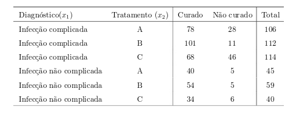

```r
 rm(list=ls())
   resim<-c(78,101,68,40,54,34)
   resnao<-c(28,11,46,5,5,6)
   diag<-c(1,1,1,0,0,0)
   trat<-c(1,2,3,1,2,3)
   dados<-as.data.frame(cbind(resim, resnao, diag, trat))
   attach(dados)

   ajust1<-glm(cbind(resim,resnao)~diag+relevel(factor(trat),3)+diag*(relevel(factor(trat),3)),
               family=binomial(link="logit"), data=dados)
   summary(ajust1)
```

```
##
## Call:
## glm(formula = cbind(resim, resnao) ~ diag + relevel(factor(trat),
##     3) + diag * (relevel(factor(trat), 3)), family = binomial(link = "logit"),
##     data = dados)
##
## Deviance Residuals:
## [1]  0  0  0  0  0  0
##
## Coefficients:
##                                Estimate Std. Error z value Pr(>|z|)
## (Intercept)                       1.735      0.443    3.92  0.00009 ***
## diag                             -1.344      0.482   -2.79   0.0053 **
## relevel(factor(trat), 3)1         0.345      0.649    0.53   0.5951
## relevel(factor(trat), 3)2         0.645      0.644    1.00   0.3165
## diag:relevel(factor(trat), 3)1    0.289      0.711    0.41   0.6848
## diag:relevel(factor(trat), 3)2    1.181      0.743    1.59   0.1118
## ---
## Signif. codes:  0 '***' 0.001 '**' 0.01 '*' 0.05 '.' 0.1 ' ' 1
##
## (Dispersion parameter for binomial family taken to be 1)
##
##     Null deviance: 44.472600432654111557  on 5  degrees of freedom
## Residual deviance:  0.000000000000019096  on 0  degrees of freedom
## AIC: 36.42
##
## Number of Fisher Scoring iterations: 3
```

```r
   anova(ajust1, test="Chisq")
```

```
## Analysis of Deviance Table
##
## Model: binomial, link: logit
##
## Response: cbind(resim, resnao)
##
## Terms added sequentially (first to last)
##
##
##                               Df Deviance Resid. Df Resid. Dev   Pr(>Chi)
## NULL                                              5       44.5
## diag                           1    13.84         4       30.6     0.0002
## relevel(factor(trat), 3)       2    28.11         2        2.5 0.00000079
## diag:relevel(factor(trat), 3)  2     2.51         0        0.0     0.2844
##
## NULL
## diag                          ***
## relevel(factor(trat), 3)      ***
## diag:relevel(factor(trat), 3)
## ---
## Signif. codes:  0 '***' 0.001 '**' 0.01 '*' 0.05 '.' 0.1 ' ' 1
```

```r
   ajust2<-glm(cbind(resim,resnao)~diag+relevel(factor(trat),3), family=binomial(link="logit"),
               data=dados)
   summary(ajust2)
```

```
##
## Call:
## glm(formula = cbind(resim, resnao) ~ diag + relevel(factor(trat),
##     3), family = binomial(link = "logit"), data = dados)
##
## Deviance Residuals:
##       1        2        3        4        5        6
## -0.0772   0.6460  -0.3445   0.1624  -1.1823   0.7406
##
## Coefficients:
##                           Estimate Std. Error z value   Pr(>|z|)
## (Intercept)                  1.418      0.299    4.75 0.00000205 ***
## diag                        -0.962      0.300   -3.21     0.0013 **
## relevel(factor(trat), 3)1    0.585      0.264    2.21     0.0268 *
## relevel(factor(trat), 3)2    1.561      0.316    4.94 0.00000078 ***
## ---
## Signif. codes:  0 '***' 0.001 '**' 0.01 '*' 0.05 '.' 0.1 ' ' 1
##
## (Dispersion parameter for binomial family taken to be 1)
##
##     Null deviance: 44.4726  on 5  degrees of freedom
## Residual deviance:  2.5147  on 2  degrees of freedom
## AIC: 34.94
##
## Number of Fisher Scoring iterations: 4
```

```r
   anova(ajust2, test="Chisq")
```

```
## Analysis of Deviance Table
##
## Model: binomial, link: logit
##
## Response: cbind(resim, resnao)
##
## Terms added sequentially (first to last)
##
##
##                          Df Deviance Resid. Df Resid. Dev   Pr(>Chi)
## NULL                                         5       44.5
## diag                      1     13.8         4       30.6     0.0002 ***
## relevel(factor(trat), 3)  2     28.1         2        2.5 0.00000079 ***
## ---
## Signif. codes:  0 '***' 0.001 '**' 0.01 '*' 0.05 '.' 0.1 ' ' 1
```

```r
   cbind(ajust2$fitted.values, ajust2$y)
```

```
##     [,1]   [,2]
## 1 0.7391 0.7358
## 2 0.8826 0.9018
## 3 0.6123 0.5965
## 4 0.8811 0.8889
## 5 0.9516 0.9153
## 6 0.8051 0.8500
```

```r
   dev<-residuals(ajust2, type='deviance'); dev
```

```
##        1        2        3        4        5        6
## -0.07716  0.64598 -0.34451  0.16245 -1.18235  0.74056
```

```r
   QL<-sum(dev^2)
   p1<-1-pchisq(QL,2)
   cbind(QL,p1)
```

```
##         QL     p1
## [1,] 2.515 0.2844
```

```r
   rpears<-residuals(ajust2, type='pearson'); rpears
```

```
##        1        2        3        4        5        6
## -0.07726  0.62995 -0.34533  0.16089 -1.30201  0.71706
```

```r
   QP<-sum(rpears^2)
   p2<-1-pchisq(QP,2)
   cbind(QP,p2)
```

```
##         QP     p2
## [1,] 2.757 0.2519
```

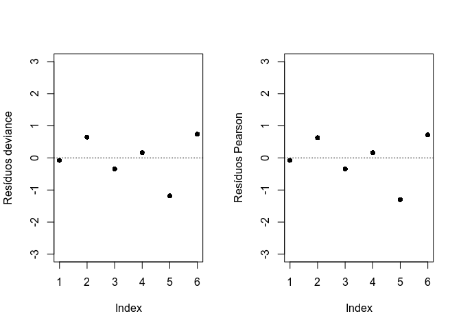

```r
   par(mfrow=c(1,2))
   plot(dev, pch=16, ylim=c(-3,3), ylab="Resíduos deviance")
   abline(h=0, lty=3)
   plot(rpears, pch=16, ylim=c(-3,3), ylab="Resíduos Pearson")
   abline(h=0, lty=3)
```

```r
   par(mfrow=c(1,1))
   ntot<-c(106,112,114,45,59,40)
   fit.model<-ajust2
   fit.model
```

```
##
## Call:  glm(formula = cbind(resim, resnao) ~ diag + relevel(factor(trat),
##     3), family = binomial(link = "logit"), data = dados)
##
## Coefficients:
##               (Intercept)                       diag
##                     1.418                     -0.962
## relevel(factor(trat), 3)1  relevel(factor(trat), 3)2
##                     0.585                      1.561
##
## Degrees of Freedom: 5 Total (i.e. Null);  2 Residual
## Null Deviance:       44.5
## Residual Deviance: 2.51  AIC: 34.9
```